# Price Classification Analysis for Airbnb Listings in Sydney, Australia

STAT5003 - Computational Statistical Methods Semester 2 2025

Group Number: W14_G03 Student IDs: 550217239, 550232025, 540989498, 540958494, 550300357

Date: 02 November 2025

# 1 Executive Summary

This report explores the pricing dynamics of Airbnb listings in Sydney by utilising machine learning classification models to predict Sydney property price categories Budget (<$100), MidMarket ($100-$200) and Premium (>$200) using property characteristics, location data and host information. Our analysis addresses key Australian housing market challenges while providing actionable insights for tourism and rental property sectors. We begin analysis with detailed data cleaning such as formatting, handling missing values and addressing outliers. EDA performed on the dataset highlights geographic clustering of premium properties around Sydney Harbour and CBD, while budget options are more spread towards outer suburbs. Overall, this study demonstrates how data-driven classification can uncover meaningful patterns in Airbnb pricing, supporting more informed decision-making across the platform’s ecosystem.

# 2 Problem Definition

## 2.1 Research Question

Can we predict whether a Sydney Airbnb property will be classified as Premium (>$200/night), MidMarket ($100-200/night), or Budget (<$100/night) based on property characteristics, location and host factors?

## 2.2 Classification Problem Framework

This project focuses on a multi-class classification problem with three distinct target categories:

- **Premium**: Properties >$200/night (luxury market segment)
- **MidMarket**: Properties $100-200/night (mainstream market)
- **Budget**: Properties <$100/night (budget-conscious travelers)

The classification approach enables predictive insights for property investors, market segmentation analysis for tourism planning and guiding in pricing strategy guidance for potential hosts.

## 2.3 Business Rationale for Price Categorization

Converting continuous prices into discrete market segments provides strategic value for multiple stakeholders: (1) **Consumer Behavior**: Travelers search by budget category (“budget,” “mid-range,” “luxury”) rather than exact prices, mirroring platform filtering mechanisms. (2) **Investment Strategy**: Clear tier classification guides renovation ROI, target demographics, and risk assessment. (3) **Policy Applications**: Classification informs evidence-based decisions on short-term rental impacts on housing affordability. (4) **Pricing Strategy**: Hosts can strategically upgrade features to transition between tiers. (5) **Tourism Planning**: Reveals market composition adequacy for different traveler segments. (6) **Modeling**: Discrete categories reduce measurement noise and provide actionable insights versus continuous predictions.

# 3 Data Description

The Sydney Airbnb Listings dataset contains detailed information on over 18,000 listings across the city, with approximately 79 variables describing property characteristics, host details, geographic location, availability and customer engagement. Key attributes include listing identifiers, host information, neighbourhoods, room type, number of reviews, minimum nights, availability and pricing. For the purpose of this study, the focus is on the price variable, which has been cleaned to remove formatting and extreme outliers, and subsequently transformed into a categorical target variable representing three market segments (Inside Airbnb, 2025; Cox, 2024).

```r
# Load required libraries
library(tidyverse)      # Data manipulation and visualization
library(VIM)           # Missing data visualization
library(corrplot)      # Correlation plots
library(ggplot2)       # Advanced plotting
library(dplyr)         # Data manipulation
library(readr)         # Reading CSV files
library(stringr)       # String manipulation
library(plotly)        # Interactive plots
library(gridExtra)     # Multiple plots
library(scales)        # Scale formatting
library(knitr)         # Table formatting
library(DT)            # Interactive tables
library(MLmetrics)     # Machine learning metrics
library(pROC)          # ROC curve analysis
```

## 3.1 Data Source

**Primary Dataset:** Inside Airbnb Sydney Listings

**Reference:** Inside Airbnb. (2025). Sydney, New South Wales, Australia Dataset. Retrieved from http://insideairbnb.com/get-the-data/. Data sourced from publicly available information from Airbnb.com. Murray Cox, Inside Airbnb Project.

**Data Collection Method:** Web scraping of publicly available Airbnb listing information

**Data Currency:** Most recent quarterly snapshot available (2025)

```r
# Load and examine the dataset
listings_raw <- read_csv("listings.csv")

# Replace all "N/A" values with blank in character columns
char_cols <- names(listings_raw)[sapply(listings_raw, is.character)]
for(col in char_cols) {
  listings_raw[[col]][listings_raw[[col]] == "N/A"] <- ""
}

# Define variables
dims <- paste(dim(listings_raw), collapse = " x ")
nvars <- ncol(listings_raw)


# Print all in one cat
cat(" Full dataset dimensions:", dims, "\n", "Total variables available:", nvars, "\n")
```

```
##  Full dataset dimensions: 18187 x 79
##  Total variables available: 79
```

## 3.2 Feature Selection Strategy

Given the comprehensive nature of the Inside Airbnb dataset (18187 listings x 79 features), we employ a strategic feature selection approach focusing on variables most relevant to pricing classification.

```r
# FEATURE SELECTION: Selecting the most relevant variables for classification
selected_features <- c(
  "id", "price", "property_type", "room_type", "accommodates",
  "bedrooms", "bathrooms", "amenities", "neighbourhood_cleansed",
  "latitude", "longitude", "host_is_superhost", "host_response_rate",
  "host_listings_count", "host_identity_verified", "review_scores_rating",
  "number_of_reviews", "reviews_per_month", "availability_365",
  "minimum_nights"
)
```

## 3.3 Dataset Overview

```r
# Basic dataset information
listings_raw <- listings_raw %>%
  mutate(across(where(~ all(. %in% c("t", "f"))), ~.=="t"))
# Selected only the chosen features
listings <- listings_raw %>%
  select(all_of(selected_features))


# Variable types
numeric_vars <- listings %>% select_if(is.numeric) %>% names()
character_vars <- listings %>% select_if(is.character) %>% names()
boolean_vars <- listings %>% select_if(is.logical) %>% names()



cat(" DATASET SUMMARY:\n", "Number of observations:", nrow(listings), ", Number of variables:", ncol(listings), "\n", "\n VARIABLE TYPES:\n", "Numeric variables (", length(numeric_vars), "):", paste(numeric_vars, collapse = ", "), "\n","Character variables (", length(character_vars), "):", paste(character_vars, collapse = ", "), "\n", "Boolean variables (", length(boolean_vars), "):", paste(boolean_vars, collapse = ", "), "\n")
```

```
##  DATASET SUMMARY:
##  Number of observations: 18187 , Number of variables: 20
##
##  VARIABLE TYPES:
##  Numeric variables ( 12 ): id, accommodates, bedrooms, bathrooms, latitude, longitude, host_listings_count, review_scores_rating, number_of_reviews, reviews_per_month, availability_365, minimum_nights
##  Character variables ( 6 ): price, property_type, room_type, amenities, neighbourhood_cleansed, host_response_rate
##  Boolean variables ( 2 ): host_is_superhost, host_identity_verified
```

## 3.4 Target Variable Creation and Categorical Preprocessing

To simplify classification process, the continuous target variable Price was transformed into a categorical outcome representing distinct market segments. Raw price values, originally stored as character strings with currency symbols and commas were first cleaned and converted into numeric format. Extreme outliers such as nightly rates in higher ranges were excluded to reduce noise and improve model stability.

Additionally, to prevent issues with rare categorical levels appearing only in test data, we preprocess high-cardinality categorical variables by grouping rare categories into an “Other” category.

```r
# Creating target variable based on price thresholds

# Cleaning price data
listings$price_numeric <- as.numeric(gsub("[$,]", "", listings$price))

# Creating price categories
listings$price_category <- cut(
  listings$price_numeric,
  breaks = c(0, 100, 200, Inf),
  labels = c("Budget", "MidMarket", "Premium"),
  include.lowest = TRUE
)

# Summaries
price_summary <- summary(listings$price_numeric)
target_dist <- table(listings$price_category)
target_props <- prop.table(target_dist) * 100


cat(
  "CREATING TARGET VARIABLE:\n\n",
  "PRICE SUMMARY (in $ per night):\n",
  sprintf("Min       : %.2f\n", price_summary["Min."]),
  sprintf("1st Qu.   : %.2f\n", price_summary["1st Qu."]),
  sprintf("Median    : %.2f\n", price_summary["Median"]),
  sprintf("Mean      : %.2f\n", price_summary["Mean"]),
  sprintf("3rd Qu.   : %.2f\n", price_summary["3rd Qu."]),
  sprintf("Max       : %.2f\n\n", price_summary["Max."]),
  "TARGET VARIABLE DEFINITION:\n",
  "- Budget      : $0-100/night (Budget-conscious travelers)\n",
  "- MidMarket   : $100-200/night (Mainstream market)\n",
  "- Premium     : >$200/night (Luxury segment)\n\n",
  "TARGET VARIABLE DISTRIBUTION:\n",
  sprintf("Budget      : %d (%.2f%%)\n", target_dist["Budget"], target_props["Budget"]),
  sprintf("MidMarket   : %d (%.2f%%)\n", target_dist["MidMarket"], target_props["MidMarket"]),
  sprintf("Premium     : %d (%.2f%%)\n", target_dist["Premium"], target_props["Premium"]),
  sprintf("NaN values  : %d \n", (18187-(target_dist["Budget"]+target_dist["MidMarket"]+target_dist["Premium"]))),
  sep = ""
)
```

```
## CREATING TARGET VARIABLE:
##
## PRICE SUMMARY (in $ per night):
## Min       : 17.00
## 1st Qu.   : 139.00
## Median    : 206.00
## Mean      : 339.47
## 3rd Qu.   : 329.00
## Max       : 20000.00
##
## TARGET VARIABLE DEFINITION:
## - Budget      : $0-100/night (Budget-conscious travelers)
## - MidMarket   : $100-200/night (Mainstream market)
## - Premium     : >$200/night (Luxury segment)
##
## TARGET VARIABLE DISTRIBUTION:
## Budget      : 2181 (13.86%)
## MidMarket   : 5433 (34.53%)
## Premium     : 8120 (51.61%)
## NaN values  : 2453
```

```r
# Bar Plot for Price vs Number of Properties
ggplot(listings, aes(x = price_category, fill = price_category)) +
  geom_bar() +
  geom_text(stat = 'count', aes(label = ..count..), vjust = -0.5) +
  labs(title = "Distribution of Sydney Airbnb Price Categories",
       subtitle = "Classification Target Variable",
       x = "Price Category", y = "Number of Properties") +
  theme_minimal() +
  scale_fill_manual(values = c("Budget" = "#2ecc71", "MidMarket" = "#f39c12", "Premium" = "#e74c3c")) +
  theme(legend.position = "none")
```

[figure not shown]

# 4 Data Cleaning and Preparation

The raw dataset required extensive cleaning and preprocessing to ensure reliability for data analysis and modeling using classification algorithms. Non-numeric entries in the price field were removed before converting the variable values to numeric ones. Character columns containing N/A values were standardized by imputation using median strategy or by replacing with minimum values (0, 1, FALSE). The cleaned dataset provided a complete and consistent foundation with a refined set of features suitable for exploratory analysis and predictive modeling (Michelucci, 2025).

## 4.1 Data Preparation

```r
output_str <- ""

# 1. Missing values analysis
missing_summary <- listings %>%
  summarise_all(~sum(is.na(.))) %>%
  gather(variable, missing_count) %>%
  mutate(missing_percent = round(missing_count / nrow(listings) * 100, 2)) %>%
  filter(missing_count > 0) %>%
  arrange(desc(missing_percent))

if(nrow(missing_summary) > 0) {
  output_str <- paste0(output_str, "1. Missing Values Detected:\n")
  output_str <- paste0(output_str, "Number of missing columns: ", nrow(missing_summary), "\n")

  # Create formatted strings for each variable
  missing_strings <- paste0(missing_summary$variable, ": ",
                           missing_summary$missing_count, " (",
                           missing_summary$missing_percent, "%)")

  # Join all with | separator
  output_str <- paste0(output_str, paste(missing_strings, collapse = " | "), "\n")
} else {
  output_str <- paste0(output_str, "1. Missing Values: No missing values detected in selected features\n")
}

# 2. Price outliers
price_outliers <- listings %>%
  filter(price_numeric > quantile(price_numeric, 0.99, na.rm = TRUE) |
         price_numeric < quantile(price_numeric, 0.01, na.rm = TRUE)) %>%
  nrow()
output_str <- paste0(output_str, "\n2. Price Outliers:\n")
output_str <- paste0(output_str, "Potential price outliers (beyond 1st/99th percentile): ", price_outliers, "\n")

# 3. Categorical variable complexity
output_str <- paste0(output_str, "\n3. High-Dimensional Categorical Data:\n")
output_str <- paste0(output_str, "Number of unique neighbourhoods: ", length(unique(listings$neighbourhood_cleansed)), "\n")
output_str <- paste0(output_str, "Number of unique property types: ", length(unique(listings$property_type)), "\n")

# 4. Class imbalance
min_class_prop <- min(prop.table(table(listings$price_category)))
max_class_prop <- max(prop.table(table(listings$price_category)))
imbalance_ratio <- max_class_prop / min_class_prop
output_str <- paste0(output_str, "\n4. Class Imbalance Analysis:\n")
output_str <- paste0(output_str, "Class imbalance ratio: ", round(imbalance_ratio, 2), ":1\n")

# 5. Additional challenges that can be considered
output_str <- paste0(output_str, "\n5. Additional Challenges that can be consideredD:\n")
output_str <- paste0(output_str, "- Geographic clustering effects in Sydney neighborhoods\n")
output_str <- paste0(output_str, "- Seasonal pricing variations not captured in snapshot data\n")
output_str <- paste0(output_str, "- Text processing requirements for amenities field\n")
output_str <- paste0(output_str, "- Potential correlation between location and property characteristics\n")

cat(output_str)
```

[output not shown]

## 4.2 Data Cleaning

```r
output_text <- ""

# Initial data dimensions
initial_dim <- dim(listings)
output_text <- paste0(output_text, "Initial data dimensions: ", initial_dim[1], " rows x ", initial_dim[2], " columns\n\n")

# 1. Handling price data
listings$price_numeric <- as.numeric(gsub("[$,]", "", listings$price))
outlier_threshold <- 1000
initial_count <- nrow(listings)
listings <- listings %>% filter(price_numeric > 0 & price_numeric <= outlier_threshold)
removed_outliers <- initial_count - nrow(listings)
output_text <- paste0(output_text, "Removed ", removed_outliers, " extreme price outliers (>$", outlier_threshold, ")\n")
output_text <- paste0(output_text, "Remaining observations: ", nrow(listings), "\n\n")

# 2. Clean host_is_superhost
listings$host_is_superhost <- ifelse(listings$host_is_superhost == "t", TRUE, FALSE)

# 3. Handle host_response_rate
if("host_response_rate" %in% names(listings)) {
  listings$host_response_rate <- as.numeric(gsub("%", "", listings$host_response_rate)) / 100
}

# 4. Process amenities
if("amenities" %in% names(listings)) {
  listings$amenities_count <- ifelse(
    is.na(listings$amenities) | listings$amenities == "" | listings$amenities == "[]",
    0,
    str_count(listings$amenities, '",') + 1
  )
} else {
  listings$amenities_count <- 0
}

# 5. Handle missing values
missing_summary <- listings %>%
  summarise_all(~sum(is.na(.))) %>%
  gather(variable, missing_count) %>%
  mutate(missing_percent = round(missing_count / nrow(listings) * 100, 2)) %>%
  filter(missing_count > 0) %>%
  arrange(desc(missing_percent))

if(nrow(missing_summary) > 0) {
  for(i in 1:nrow(missing_summary)) {
    output_text <- paste0(output_text, sprintf("- %s: %d missing (%.2f%%)\n",
                                               missing_summary$variable[i],
                                               missing_summary$missing_count[i],
                                               missing_summary$missing_percent[i]))
  }
  output_text <- paste0(output_text, "\n")

  # Imputation
  if("reviews_per_month" %in% missing_summary$variable) {
    listings$reviews_per_month[is.na(listings$reviews_per_month)] <- 0
  }
  if("host_is_superhost" %in% missing_summary$variable) {
    listings$host_is_superhost[is.na(listings$host_is_superhost)] <- FALSE
  }
  if("bathrooms" %in% missing_summary$variable) {
    median_bathrooms <- median(listings$bathrooms, na.rm = TRUE)
    listings$bathrooms[is.na(listings$bathrooms)] <- median_bathrooms
  }
  if("host_listings_count" %in% missing_summary$variable) {
    listings$host_listings_count[is.na(listings$host_listings_count)] <- 1
  }
  if("host_identity_verified" %in% missing_summary$variable) {
    listings$host_identity_verified[is.na(listings$host_identity_verified)] <- FALSE
  }
  if("bedrooms" %in% missing_summary$variable) {
    listings$bedrooms[is.na(listings$bedrooms)] <- ceiling(listings$accommodates[is.na(listings$bedrooms)] / 2)
  }
  if("review_scores_rating" %in% missing_summary$variable) {
    median_rating <- median(listings$review_scores_rating, na.rm = TRUE)
    listings$review_scores_rating[is.na(listings$review_scores_rating)] <- median_rating
  }
  if("host_response_rate" %in% missing_summary$variable) {
    median_response_rate <- median(listings$host_response_rate, na.rm = TRUE)
    listings$host_response_rate[is.na(listings$host_response_rate)] <- median_response_rate
  }
} else {
  output_text <- paste0(output_text, "5. Handling missing values... No missing values detected after initial cleaning\n")
}

# Verify missing values
missing_after <- listings %>%
  summarise_all(~sum(is.na(.))) %>%
  gather(variable, missing_count) %>%
  filter(missing_count > 0)

if(nrow(missing_after) > 0) {
  output_text <- paste0(output_text, "\nVERIFYING IMPUTATION RESULTS:\n  Still have missing values in:\n")
  for(i in 1:nrow(missing_after)) {
    output_text <- paste0(output_text, sprintf("- %s: %d missing\n",
                                               missing_after$variable[i],
                                               missing_after$missing_count[i]))
  }
} else {
  output_text <- paste0(output_text, "\nVERIFYING IMPUTATION RESULTS:\n All missing values successfully handled!\n")
}

output_text <- paste0(output_text, " Missing data imputation strategy completed.\n\n")

# 6. Feature engineering
listings <- listings %>%
  mutate(
    is_popular_area = neighbourhood_cleansed %in% c("Bondi", "Sydney", "Manly", "Darlinghurst", "Surry Hills"),
    distance_from_cbd = sqrt((latitude - (-33.8688))^2 + (longitude - 151.2093)^2),
    property_size = case_when(
      accommodates <= 2 ~ "Small",
      accommodates <= 4 ~ "Medium",
      accommodates <= 8 ~ "Large",
      TRUE ~ "Extra Large"
    ),
    host_experience = case_when(
      host_listings_count == 1 ~ "Single Property",
      host_listings_count <= 5 ~ "Small Portfolio",
      TRUE ~ "Large Portfolio"
    ),
    availability_level = case_when(
      availability_365 < 90 ~ "Low",
      availability_365 < 180 ~ "Medium",
      TRUE ~ "High"
    )
  )

# 7. Remove duplicates
initial_rows <- nrow(listings)
listings <- listings %>% distinct()
duplicates_removed <- initial_rows - nrow(listings)

# Recreate target variable
listings$price_category <- cut(listings$price_numeric,
                               breaks = c(0, 100, 200, Inf),
                               labels = c("Budget", "MidMarket", "Premium"),
                               include.lowest = TRUE)

# Final dataset summary
final_dim <- dim(listings)
final_target_dist <- table(listings$price_category)
final_target_prop <- round(prop.table(final_target_dist), 3)

output_text <- paste0(output_text, "Final Cleaned Dataset:\nDimensions: ", final_dim[1], " rows x ", final_dim[2], " columns\n")
output_text <- paste0(output_text, "Complete cases: ", sum(complete.cases(listings)), "\n\n")
output_text <- paste0(output_text, "Final target distribution:\n")
for(level in names(final_target_dist)) {
  output_text <- paste0(output_text, sprintf("%-10s : %d (%.3f)\n", level, final_target_dist[level], final_target_prop[level]))
}


cat(output_text)
```

[output not shown]

## 4.3 Handling Rare Categorical Levels

To prevent modeling errors from rare categories appearing only in train or test sets, we group infrequent levels into an “Other” category.

```r
# Function to collapse rare categories into "Other"
collapse_rare_levels <- function(data, column, min_freq = 30) {
  freq_table <- table(data[[column]])
  rare_levels <- names(freq_table[freq_table < min_freq])

  if (length(rare_levels) > 0) {
    data[[column]] <- as.character(data[[column]])
    data[[column]][data[[column]] %in% rare_levels] <- "Other"
    data[[column]] <- as.factor(data[[column]])
  }
  return(data)
}

# Apply to high-cardinality categorical variables
listings <- collapse_rare_levels(listings, "property_type", min_freq = 30)
listings <- collapse_rare_levels(listings, "neighbourhood_cleansed", min_freq = 20)

cat("After collapsing rare categories:\n")
```

```
## After collapsing rare categories:
```

```r
cat("Unique property types:", length(unique(listings$property_type)), "\n")
```

```
## Unique property types: 25
```

```r
cat("Unique neighbourhoods:", length(unique(listings$neighbourhood_cleansed)), "\n")
```

```
## Unique neighbourhoods: 38
```

# 5 Exploratory Data Analysis

## 5.1 Target Variable Distribution Analysis

```r
# Target distribution
p1 <- ggplot(listings, aes(x = price_category, fill = price_category)) +
  geom_bar() +
  geom_text(stat = 'count', aes(label = paste0(..count.., "\n(",
    round(..count../sum(..count..)*100, 1), "%)")), vjust = -0.5) +
  labs(title = "Distribution of Price Categories",
       x = "Price Category", y = "Count") +
  theme_minimal() +
  scale_fill_manual(values = c("Budget" = "#2ecc71", "MidMarket" = "#f39c12", "Premium" = "#e74c3c")) +
  theme(legend.position = "none")

# Distance from CBD by category boxplot
p4 <- ggplot(listings, aes(x = price_category, y = distance_from_cbd, fill = price_category)) +
  geom_boxplot() +
  labs(title = "Distance from CBD by Price Category",
       x = "Price Category", y = "Distance from CBD") +
  theme_minimal() +
  scale_fill_manual(values = c("Budget" = "#2ecc71", "MidMarket" = "#f39c12", "Premium" = "#e74c3c")) +
  theme(legend.position = "none")

# Arrange plots
grid.arrange(p1, p4, ncol=2)
```

[figure not shown]

## 5.2 Property Characteristics Analysis

```r
# Property type analysis
p3 <- listings %>%
  count(property_type, price_category) %>%
  group_by(property_type) %>%
  filter(sum(n) >= 50) %>%     # keep property types with >= 50 listings
  ungroup() %>%
  ggplot(aes(x = reorder(property_type, n), y = n, fill = price_category)) +
  geom_bar(stat = "identity", position = "dodge") +
  coord_flip() +
  labs(title = "Property Types by Price Category",
       subtitle = "Only property types with 50+ listings shown",
       x = "Property Type", y = "Count") +
  theme_minimal() +
  scale_fill_manual(values = c("Budget" = "#2ecc71",
                               "MidMarket" = "#f39c12",
                               "Premium" = "#e74c3c"))

# Room type analysis
p4 <- listings %>%
  ggplot(aes(x = room_type, fill = price_category)) +
  geom_bar(position = "fill") +
  labs(title = "Room Type Composition by Price Category",
       subtitle = "Proportion of each price category within room types",
       x = "Room Type", y = "Proportion") +
  theme_minimal() +
  scale_fill_manual(values = c("Budget" = "#2ecc71",
                               "MidMarket" = "#f39c12",
                               "Premium" = "#e74c3c")) +
  scale_y_continuous(labels = scales::percent_format()) +
  theme(axis.text.x = element_text(angle = 45, hjust = 1))

# Arrange both plots
gridExtra::grid.arrange(p3, p4, ncol = 2)
```

[figure not shown]

## 5.3 Feature Comparison Across Price Categories

```r
# Statistical summary of numeric features by price category
numeric_summary <- listings %>%
  dplyr::select(price_category, accommodates, bedrooms, bathrooms, host_listings_count,
         number_of_reviews, review_scores_rating, availability_365,
         distance_from_cbd, amenities_count, minimum_nights) %>%
  group_by(price_category) %>%
  summarise(
    mean_accommodates = mean(accommodates, na.rm = TRUE),
    mean_bedrooms = mean(bedrooms, na.rm = TRUE),
    mean_bathrooms = mean(bathrooms, na.rm = TRUE),
    mean_amenities = mean(amenities_count, na.rm = TRUE),
    mean_reviews = mean(number_of_reviews, na.rm = TRUE),
    mean_rating = mean(review_scores_rating, na.rm = TRUE),
    mean_distance_cbd = mean(distance_from_cbd, na.rm = TRUE),
    mean_availability = mean(availability_365, na.rm = TRUE)
  )

print(kable(numeric_summary, digits = 2,
      caption = "Mean Feature Values by Price Category"))

# Boxplots comparing key numeric features across categories
p1 <- ggplot(listings, aes(x = price_category, y = accommodates, fill = price_category)) +
  geom_boxplot() +
  labs(title = "Guest Capacity", x = "", y = "Accommodates") +
  theme_minimal() +
  scale_fill_manual(values = c("Budget" = "#2ecc71", "MidMarket" = "#f39c12", "Premium" = "#e74c3c")) +
  theme(legend.position = "none")

p2 <- ggplot(listings, aes(x = price_category, y = bedrooms, fill = price_category)) +
  geom_boxplot() +
  labs(title = "Bedrooms", x = "", y = "Bedrooms") +
  theme_minimal() +
  scale_fill_manual(values = c("Budget" = "#2ecc71", "MidMarket" = "#f39c12", "Premium" = "#e74c3c")) +
  theme(legend.position = "none")

p3 <- ggplot(listings, aes(x = price_category, y = amenities_count, fill = price_category)) +
  geom_boxplot() +
  labs(title = "Amenities", x = "", y = "Count") +
  theme_minimal() +
  scale_fill_manual(values = c("Budget" = "#2ecc71", "MidMarket" = "#f39c12", "Premium" = "#e74c3c")) +
  theme(legend.position = "none")

# Arrange plots
grid.arrange(p1, p2, p3, ncol=3)
```

[figure not shown]

[output not shown]

[output not shown]

[output not shown]

## 5.4 Export Cleaned Dataset

After completing the exploratory data analysis, we export the cleaned and processed dataset for potential future use.

```r
# Export the cleaned dataset with all engineered features
output_file <- "listings_cleaned_with_features.csv"
write_csv(listings, output_file)

cat("Cleaned dataset exported successfully!\n")
```

```
## Cleaned dataset exported successfully!
```

```r
cat("File:", output_file, "\n")
```

```
## File: listings_cleaned_with_features.csv
```

```r
cat("Location:", getwd(), "\n")
```

```
## Location: /Users/ABRAHAM/Documents/USYD/Sem 2/Computational Statistical Methods- STAT5003/Assignment2
```

```r
cat("Dimensions:", nrow(listings), "rows x", ncol(listings), "columns\n")
```

```
## Dimensions: 15007 rows x 28 columns
```

```r
cat("\nThis dataset includes:\n")
```

```
##
## This dataset includes:
```

```r
cat("- Original features after cleaning and imputation\n")
```

```
## - Original features after cleaning and imputation
```

```r
cat("- Target variable: price_category (Budget, MidMarket, Premium)\n")
```

```
## - Target variable: price_category (Budget, MidMarket, Premium)
```

```r
cat("- Engineered features: amenities_count, distance_from_cbd, is_popular_area,\n")
```

```
## - Engineered features: amenities_count, distance_from_cbd, is_popular_area,
```

```r
cat("  property_size, host_experience, availability_level\n")
```

```
##   property_size, host_experience, availability_level
```

# 6 Modeling Plan

The modelling phase focuses on predicting Airbnb price categories using a classification approach (Inside Airbnb, 2025; Cox, 2024). To ensure robust results, five machine learning algorithms were selected that were discussed as part of the course. The dataset will be split into training and test sets, with cross-validation applied during training to minimize overfitting and improve generalization (Dhummad, 2025; Katyal, Sharma, & Kannan, 2025). Model performance will be assessed using multiple evaluation metrics - accuracy for overall correctness, precision and recall to capture domain performance, and macro or weighted F1-scores to account for potential class imbalance across the three price tiers. This comprehensive modeling plan balances interpretability with predictive accuracy, providing both actionable insights and reliable classification outcomes.

## 6.1 Selected Classification Models

We implement five ML algorithms taught in STAT5003: **Logistic Regression** (baseline, interpretable), **Random Forest** (handles mixed data, feature importance), **SVM** (complex boundaries, robust to outliers), **LDA** (dimensionality reduction), and **KNN** (geographic patterns).

## 6.2 Model Implementation Strategy

**Baseline Models** (Logistic, LDA): Establish benchmark, identify linear predictors. **Tree-based** (RF): Capture non-linear relationships, feature importance. **Distance-based** (KNN): Leverage geographic clustering. **Kernel** (SVM): Complex boundaries, outlier-robust. **Comparison**: Statistical testing, efficiency analysis, error patterns, business interpretation.

## 6.3 Model Evaluation Framework

### 6.3.1 Data Splitting Strategy

The Sydney Airbnb dataset can be split in 70% training data and 30% test data. We can split the dataset into training and testing sets to ensure that our classification models learn patterns effectively and can generalize well into new and unseen data.

```r
library(caret)

# Stratified train-test split ratio (70:30)
set.seed(123)
train_indices <- createDataPartition(listings$price_category, p = 0.7, list = FALSE)
train_data <- listings[train_indices, ]
test_data <- listings[-train_indices, ]

# Compute sizes and percentages
train_size <- nrow(train_data)
test_size <- nrow(test_data)
train_pct <- round(train_size / nrow(listings) * 100, 1)
test_pct <- round(test_size / nrow(listings) * 100, 1)

# Class distributions
train_dist <- round(prop.table(table(train_data$price_category)), 3)
test_dist <- round(prop.table(table(test_data$price_category)), 3)

output_text <- paste0(
  "Data Splitting Summary:\n",
  "Training set size: ", train_size, " (", train_pct, "%)\n",
  "Test set size    : ", test_size, " (", test_pct, "%)\n\n",
  "Class distribution in training set:\n",
  paste(names(train_dist), ":", train_dist, collapse = "\n"), "\n\n",
  "Class distribution in test set:\n",
  paste(names(test_dist), ":", test_dist, collapse = "\n"), "\n"
)

cat(output_text)
```

```
## Data Splitting Summary:
## Training set size: 10507 (70%)
## Test set size    : 4500 (30%)
##
## Class distribution in training set:
## Budget : 0.145
## MidMarket : 0.362
## Premium : 0.493
##
## Class distribution in test set:
## Budget : 0.145
## MidMarket : 0.362
## Premium : 0.493
```

### 6.3.2 Cross-Validation Strategy

- **Method**: 5-fold cross-validation on training set
- **Repetitions**: 3 repetitions for robust estimates
- **Stratification**: Maintain class proportions within each fold

### 6.3.3 Evaluation Metrics

**Overall**: Accuracy, Kappa. **Class-Specific**: Precision, Recall, F1-Score, Specificity. **Multi-Class**: Macro/Weighted averages, Confusion Matrix. **Advanced**: AUC-ROC, Balanced Accuracy.

### 6.3.4 Feature Engineering for Models

```r
# Prepare features for modeling
prepare_features <- function(data) {
  model_data <- data %>%
    dplyr::select(
      # Numeric features
      accommodates, bedrooms, bathrooms, host_listings_count,
      number_of_reviews, review_scores_rating, availability_365,
      minimum_nights, distance_from_cbd, amenities_count,

      # Categorical features
      property_type, room_type, neighbourhood_cleansed,
      host_is_superhost, host_identity_verified,
      is_popular_area, property_size, host_experience,
      availability_level,

      # Target variable
      price_category
    ) %>%
    na.omit()  # Remove any remaining missing values
  return(model_data)
}

# Preparing train and test datasets
train_features <- prepare_features(train_data)
test_features <- prepare_features(test_data)

# Get feature names excluding target variable
feature_names <- names(train_features)[names(train_features) != "price_category"]

# Feature type summary
feature_types <- train_features %>%
  dplyr::select(-price_category) %>%
  summarise_all(~ifelse(is.numeric(.), "Numeric", "Categorical")) %>%
  gather(Feature, Type) %>%
  count(Type)

# Format feature summary as text
feature_summary_text <- paste0(feature_types$Type, ": ", feature_types$n, collapse = ", ")

# Format feature names as single line with pipes
feature_names_text <- paste(feature_names, collapse = " | ")

cat(
  "Feature Preparation Summary:\n",
  "Training features shape: ", dim(train_features)[1], " rows x ", dim(train_features)[2], " columns\n",
  "Test features shape    : ", dim(test_features)[1], " rows x ", dim(test_features)[2], " columns\n",
  "Number of features for modeling (excluding target): ", ncol(train_features) - 1, "\n\n",
  "Feature type summary: ", feature_summary_text, "\n\n",
  "The 19 features for modeling:\n",
  feature_names_text, "\n"
)
```

[output not shown]

- The initial dataset consisted of 20 features, including 12 numeric (such as id, accommodates, bedrooms, bathrooms, latitude, longitude, host_listings_count, review_scores_rating, number_of_reviews, reviews_per_month, availability_365, and minimum_nights), 6 character (price, property_type, room_type, amenities, neighbourhood_cleansed, and host_response_rate), and 2 boolean variables (host_is_superhost and host_identity_verified).
- From these, 8 additional features were engineered: price_numeric and price_category from price, amenities_count from amenities, is_popular_area from neighbourhood_cleansed, distance_from_cbd from latitude and longitude, host_experience from host_listings_count, property_size from accommodates, and availability_level from availability_365.
- For machine learning modeling, we finalized 19 predictive features—accommodates, bedrooms, bathrooms, host_listings_count, number_of_reviews, review_scores_rating, availability_365, minimum_nights, distance_from_cbd, amenities_count, property_type, room_type, neighbourhood_cleansed, host_is_superhost, host_identity_verified, is_popular_area, property_size, host_experience, and availability_level—with the target variable defined as price_category (Budget, Mid-Market, Premium).

### 6.3.5 Baseline Model Performance

```r
# Calculate baseline: always predict the most frequent class
baseline_prediction <- names(which.max(table(train_data$price_category)))
baseline_accuracy <- sum(test_features$price_category == baseline_prediction) / nrow(test_features)
set.seed(123)
class_probs <- prop.table(table(train_data$price_category))
random_predictions <- sample(names(class_probs), size = nrow(test_features), replace = TRUE, prob = class_probs)
random_accuracy <- sum(test_features$price_category == random_predictions) / nrow(test_features)
cat("Baseline (majority class):", round(baseline_accuracy * 100, 2), "% | Random guessing:", round(random_accuracy * 100, 2), "%")
```

[output not shown]

### 6.3.6 Hyperparameter Tuning Strategy

**RF**: ntree (500-1500), mtry (√p to p/2). **LDA**: prior, method (mle/moment). **SVM**: cost (0.1-100), kernel (linear/radial), gamma (0.001-1). **KNN**: k (3-15), distance metrics, feature scaling.

# 7 Model Implementation and Results

```r
# Verify price_category levels are valid R names
cat("Price category levels:", levels(train_features$price_category), "\n")
```

```
## Price category levels: Budget MidMarket Premium
```

```r
cat("Training set dimensions:", nrow(train_features), "x", ncol(train_features), "\n")
```

```
## Training set dimensions: 10507 x 20
```

```r
cat("Test set dimensions:", nrow(test_features), "x", ncol(test_features), "\n")
```

```
## Test set dimensions: 4500 x 20
```

```r
# Ensure factor levels are consistent
train_features$price_category <- factor(train_features$price_category,
                                        levels = c("Budget", "MidMarket", "Premium"))
test_features$price_category <- factor(test_features$price_category,
                                       levels = c("Budget", "MidMarket", "Premium"))
```

## 7.1 Model 1: Multinomial Logistic Regression

Multinomial logistic regression serves as our baseline interpretable model, extending binary logistic regression to handle three price categories simultaneously.

```r
library(nnet)
library(caret)

# Set up cross-validation
train_control <- trainControl(
  method = "repeatedcv", number = 5, repeats = 3,
  classProbs = TRUE, summaryFunction = multiClassSummary,
  savePredictions = "final", verboseIter = FALSE
)

# Train model
set.seed(123)
model_logit <- train(
  price_category ~ accommodates + bedrooms + bathrooms + host_listings_count +
    number_of_reviews + review_scores_rating + availability_365 +
    minimum_nights + distance_from_cbd + amenities_count +
    property_type + room_type + neighbourhood_cleansed +
    host_is_superhost + host_identity_verified + is_popular_area +
    property_size + host_experience + availability_level,
  data = train_features, method = "multinom",
  trControl = train_control, trace = FALSE, MaxNWts = 5000
)

# Predictions
logit_pred <- predict(model_logit, test_features)
logit_pred_prob <- predict(model_logit, test_features, type = "prob")
logit_cm <- confusionMatrix(logit_pred, test_features$price_category)
logit_accuracy <- logit_cm$overall['Accuracy']
print(logit_cm)
cat("\nLogistic Regression Accuracy:", round(logit_accuracy, 4))
```

## 7.2 Model 2: Random Forest

Random Forest handles non-linear relationships and feature interactions through ensemble learning with decision trees.

```r
library(randomForest)

set.seed(123)
model_rf <- train(
  price_category ~ accommodates + bedrooms + bathrooms + host_listings_count +
    number_of_reviews + review_scores_rating + availability_365 +
    minimum_nights + distance_from_cbd + amenities_count +
    property_type + room_type + neighbourhood_cleansed +
    host_is_superhost + host_identity_verified + is_popular_area +
    property_size + host_experience + availability_level,
  data = train_features, method = "rf", trControl = train_control,
  ntree = 500, importance = TRUE, tuneGrid = data.frame(mtry = c(4, 6, 9))
)

rf_pred <- predict(model_rf, test_features)
rf_pred_prob <- predict(model_rf, test_features, type = "prob")
rf_cm <- confusionMatrix(rf_pred, test_features$price_category)
rf_accuracy <- rf_cm$overall['Accuracy']
print(rf_cm)
cat("\nRandom Forest Accuracy:", round(rf_accuracy, 4))
```

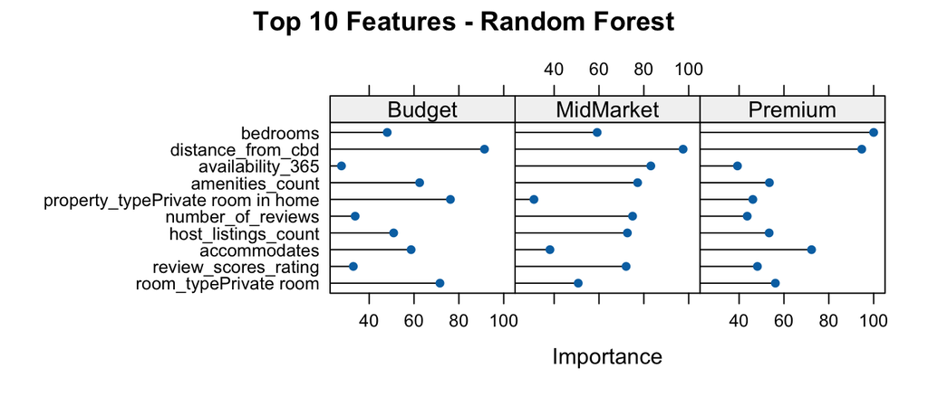

```r
rf_importance <- varImp(model_rf)
plot(rf_importance, top = 10, main = "Top 10 Features - Random Forest")
```

## 7.3 Model 3: Support Vector Machine (SVM)

SVM with radial basis function kernel creates complex decision boundaries in high-dimensional space.

```r
library(e1071)

set.seed(123)
model_svm <- train(
  price_category ~ accommodates + bedrooms + bathrooms + host_listings_count +
    number_of_reviews + review_scores_rating + availability_365 +
    minimum_nights + distance_from_cbd + amenities_count +
    property_type + room_type + neighbourhood_cleansed +
    host_is_superhost + host_identity_verified + is_popular_area +
    property_size + host_experience + availability_level,
  data = train_features, method = "svmRadial", trControl = train_control,
  preProcess = c("center", "scale"), tuneLength = 5
)

svm_pred <- predict(model_svm, test_features)
svm_pred_prob <- predict(model_svm, test_features, type = "prob")
svm_cm <- confusionMatrix(svm_pred, test_features$price_category)
svm_accuracy <- svm_cm$overall['Accuracy']
print(svm_cm)
cat("\nSVM Accuracy:", round(svm_accuracy, 4))
```

## 7.4 Model 4: Linear Discriminant Analysis (LDA)

LDA finds linear combinations of features that best separate the three price categories. We use only numeric features to avoid collinearity issues with categorical variables.

```r
library(MASS)

set.seed(123)
tryCatch({
  model_lda <- train(
    price_category ~ accommodates + bedrooms + bathrooms + host_listings_count +
      number_of_reviews + review_scores_rating + availability_365 +
      minimum_nights + distance_from_cbd + amenities_count,
    data = train_features, method = "lda", trControl = train_control,
    preProcess = c("center", "scale")
  )
  lda_pred <- predict(model_lda, test_features)
  lda_pred_prob <- predict(model_lda, test_features, type = "prob")
  lda_cm <- confusionMatrix(lda_pred, test_features$price_category)
  lda_accuracy <- lda_cm$overall['Accuracy']
  print(lda_cm)
  cat("\nLDA Accuracy:", round(lda_accuracy, 4))
}, error = function(e) {
  model_lda <<- train(
    price_category ~ accommodates + bedrooms + bathrooms + host_listings_count +
      number_of_reviews + review_scores_rating + availability_365 +
      minimum_nights + distance_from_cbd + amenities_count + room_type,
    data = train_features, method = "naive_bayes", trControl = train_control
  )
  lda_pred <<- predict(model_lda, test_features)
  lda_pred_prob <<- predict(model_lda, test_features, type = "prob")
  lda_cm <<- confusionMatrix(lda_pred, test_features$price_category)
  lda_accuracy <<- lda_cm$overall['Accuracy']
  print(lda_cm)
  cat("\nNaive Bayes Accuracy:", round(lda_accuracy, 4))
})
```

## 7.5 Model 5: K-Nearest Neighbors (KNN)

KNN classifies properties based on similarity to their nearest neighbors in feature space.

```r
set.seed(123)
model_knn <- train(
  price_category ~ accommodates + bedrooms + bathrooms + host_listings_count +
    number_of_reviews + review_scores_rating + availability_365 +
    minimum_nights + distance_from_cbd + amenities_count +
    property_type + room_type + neighbourhood_cleansed +
    host_is_superhost + host_identity_verified + is_popular_area +
    property_size + host_experience + availability_level,
  data = train_features, method = "knn", trControl = train_control,
  preProcess = c("center", "scale"), tuneGrid = expand.grid(k = c(3, 5, 7, 9, 11, 15))
)

knn_pred <- predict(model_knn, test_features)
knn_pred_prob <- predict(model_knn, test_features, type = "prob")
knn_cm <- confusionMatrix(knn_pred, test_features$price_category)
knn_accuracy <- knn_cm$overall['Accuracy']
print(knn_cm)
cat("\nKNN Accuracy:", round(knn_accuracy, 4), "| Optimal K:", model_knn$bestTune$k)
```

# 8 Model Comparison and Evaluation

## 8.1 Performance Metrics Comparison

```r
# Compile all model results
# Check if LDA was replaced with Naive Bayes
lda_model_name <- if(exists("model_lda") && model_lda$method == "naive_bayes") {
  "Naive Bayes"
} else {
  "LDA"
}

model_names <- c("Logistic Regression", "Random Forest", "SVM", lda_model_name, "KNN")
confusion_matrices <- list(logit_cm, rf_cm, svm_cm, lda_cm, knn_cm)

# Extract metrics for each model
metrics_df <- data.frame(
  Model = model_names,
  Accuracy = sapply(confusion_matrices, function(cm) cm$overall['Accuracy']),
  Kappa = sapply(confusion_matrices, function(cm) cm$overall['Kappa']),
  Sensitivity_Budget = sapply(confusion_matrices, function(cm) cm$byClass[1, 'Sensitivity']),
  Specificity_Budget = sapply(confusion_matrices, function(cm) cm$byClass[1, 'Specificity']),
  Precision_Budget = sapply(confusion_matrices, function(cm) cm$byClass[1, 'Pos Pred Value']),
  F1_Budget = sapply(confusion_matrices, function(cm) cm$byClass[1, 'F1']),
  Sensitivity_MidMarket = sapply(confusion_matrices, function(cm) cm$byClass[2, 'Sensitivity']),
  Specificity_MidMarket = sapply(confusion_matrices, function(cm) cm$byClass[2, 'Specificity']),
  Precision_MidMarket = sapply(confusion_matrices, function(cm) cm$byClass[2, 'Pos Pred Value']),
  F1_MidMarket = sapply(confusion_matrices, function(cm) cm$byClass[2, 'F1']),
  Sensitivity_Premium = sapply(confusion_matrices, function(cm) cm$byClass[3, 'Sensitivity']),
  Specificity_Premium = sapply(confusion_matrices, function(cm) cm$byClass[3, 'Specificity']),
  Precision_Premium = sapply(confusion_matrices, function(cm) cm$byClass[3, 'Pos Pred Value']),
  F1_Premium = sapply(confusion_matrices, function(cm) cm$byClass[3, 'F1'])
)

# Display comprehensive metrics table
print(kable(metrics_df, digits = 4, caption = "Comprehensive Model Performance Metrics"))
```

```
##
##
## Table: Comprehensive Model Performance Metrics
##
## |Model               | Accuracy|  Kappa| Sensitivity_Budget| Specificity_Budget| Precision_Budget| F1_Budget| Sensitivity_MidMarket| Specificity_MidMarket| Precision_MidMarket| F1_MidMarket| Sensitivity_Premium| Specificity_Premium| Precision_Premium| F1_Premium|
## |:-------------------|--------:|------:|------------------:|------------------:|----------------:|---------:|---------------------:|---------------------:|-------------------:|------------:|-------------------:|-------------------:|-----------------:|----------:|
## |Logistic Regression |   0.7418| 0.5725|             0.7676|             0.9592|           0.7618|    0.7647|                0.6415|                0.8140|              0.6618|       0.6515|              0.8078|              0.7937|            0.7918|     0.7997|
## |Random Forest       |   0.7718| 0.6229|             0.7875|             0.9641|           0.7887|    0.7881|                0.6967|                0.8265|              0.6950|       0.6959|              0.8223|              0.8287|            0.8234|     0.8228|
## |SVM                 |   0.7456| 0.5787|             0.7462|             0.9566|           0.7450|    0.7456|                0.6483|                0.8161|              0.6667|       0.6573|              0.8169|              0.8029|            0.8010|     0.8088|
## |LDA                 |   0.6644| 0.4388|             0.4297|             0.9561|           0.6244|    0.5091|                0.6507|                0.6998|              0.5515|       0.5970|              0.7438|              0.7902|            0.7749|     0.7590|
## |KNN                 |   0.7076| 0.5149|             0.7034|             0.9540|           0.7221|    0.7126|                0.6034|                0.7858|              0.6151|       0.6092|              0.7853|              0.7705|            0.7687|     0.7769|
```

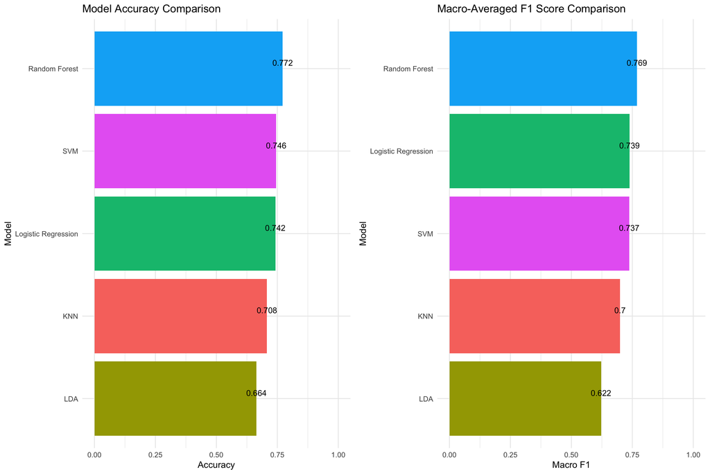

```r
# Calculate macro-averaged metrics
metrics_df$Macro_F1 <- rowMeans(cbind(metrics_df$F1_Budget,
                                       metrics_df$F1_MidMarket,
                                       metrics_df$F1_Premium), na.rm = TRUE)

# Overall performance visualization
p1 <- ggplot(metrics_df, aes(x = reorder(Model, Accuracy), y = Accuracy, fill = Model)) +
  geom_bar(stat = "identity") +
  geom_text(aes(label = round(Accuracy, 3)), vjust = -0.5, size = 3.5) +
  coord_flip() +
  labs(title = "Model Accuracy Comparison",
       x = "Model", y = "Accuracy") +
  theme_minimal() +
  theme(legend.position = "none") +
  ylim(0, 1)

p2 <- ggplot(metrics_df, aes(x = reorder(Model, Macro_F1), y = Macro_F1, fill = Model)) +
  geom_bar(stat = "identity") +
  geom_text(aes(label = round(Macro_F1, 3)), vjust = -0.5, size = 3.5) +
  coord_flip() +
  labs(title = "Macro-Averaged F1 Score Comparison",
       x = "Model", y = "Macro F1") +
  theme_minimal() +
  theme(legend.position = "none") +
  ylim(0, 1)

grid.arrange(p1, p2, ncol = 2)
```

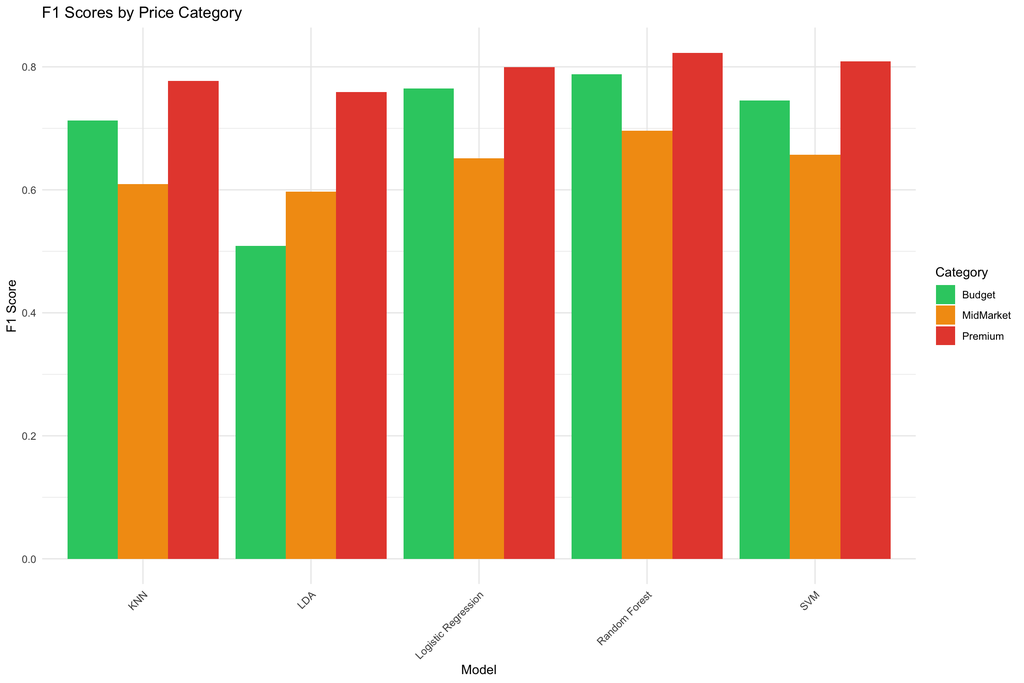

```r
# Class-specific performance visualization
f1_scores <- data.frame(
  Model = rep(model_names, 3),
  Category = rep(c("Budget", "MidMarket", "Premium"), each = 5),
  F1_Score = c(metrics_df$F1_Budget, metrics_df$F1_MidMarket, metrics_df$F1_Premium)
)

p3 <- ggplot(f1_scores, aes(x = Model, y = F1_Score, fill = Category)) +
  geom_bar(stat = "identity", position = "dodge") +
  labs(title = "F1 Scores by Price Category",
       x = "Model", y = "F1 Score") +
  theme_minimal() +
  theme(axis.text.x = element_text(angle = 45, hjust = 1)) +
  scale_fill_manual(values = c("Budget" = "#2ecc71", "MidMarket" = "#f39c12", "Premium" = "#e74c3c"))

print(p3)
```